# Risk Factor Analysis

## Outcome Variable

**Outcome Variable:** wast_rec90d

## Predictor Variables

**Intervention Variable:** mage

**Adjustment Set:**

- arm
- meducyrs
- feducyrs
- W_mhtcm
- delta_meducyrs
- delta_feducyrs
- delta_W_mhtcm

## Stratifying Variables

The analysis was stratified on these variable(s):

- agecat
- studyid
- country

## Data Summary

| agecat | studyid | country | mage | wast_rec90d | n_cell | n |
| --- | --- | --- | --- | --- | --- | --- |
| 0-24 months | ki0047075b-MAL-ED | BANGLADESH | [20-30) | 0 | 24 | 124 |
| 0-24 months | ki0047075b-MAL-ED | BANGLADESH | [20-30) | 1 | 46 | 124 |
| 0-24 months | ki0047075b-MAL-ED | BANGLADESH | <20 | 0 | 8 | 124 |
| 0-24 months | ki0047075b-MAL-ED | BANGLADESH | <20 | 1 | 17 | 124 |
| 0-24 months | ki0047075b-MAL-ED | BANGLADESH | >=30 | 0 | 13 | 124 |
| 0-24 months | ki0047075b-MAL-ED | BANGLADESH | >=30 | 1 | 16 | 124 |
| 0-24 months | ki0047075b-MAL-ED | BRAZIL | [20-30) | 0 | 3 | 23 |
| 0-24 months | ki0047075b-MAL-ED | BRAZIL | [20-30) | 1 | 11 | 23 |
| 0-24 months | ki0047075b-MAL-ED | BRAZIL | <20 | 0 | 0 | 23 |
| 0-24 months | ki0047075b-MAL-ED | BRAZIL | <20 | 1 | 4 | 23 |
| 0-24 months | ki0047075b-MAL-ED | BRAZIL | >=30 | 0 | 3 | 23 |
| 0-24 months | ki0047075b-MAL-ED | BRAZIL | >=30 | 1 | 2 | 23 |
| 0-24 months | ki0047075b-MAL-ED | INDIA | [20-30) | 0 | 58 | 177 |
| 0-24 months | ki0047075b-MAL-ED | INDIA | [20-30) | 1 | 84 | 177 |
| 0-24 months | ki0047075b-MAL-ED | INDIA | <20 | 0 | 12 | 177 |
| 0-24 months | ki0047075b-MAL-ED | INDIA | <20 | 1 | 16 | 177 |
| 0-24 months | ki0047075b-MAL-ED | INDIA | >=30 | 0 | 1 | 177 |
| 0-24 months | ki0047075b-MAL-ED | INDIA | >=30 | 1 | 6 | 177 |
| 0-24 months | ki0047075b-MAL-ED | NEPAL | [20-30) | 0 | 18 | 93 |
| 0-24 months | ki0047075b-MAL-ED | NEPAL | [20-30) | 1 | 59 | 93 |
| 0-24 months | ki0047075b-MAL-ED | NEPAL | <20 | 0 | 1 | 93 |
| 0-24 months | ki0047075b-MAL-ED | NEPAL | <20 | 1 | 2 | 93 |
| 0-24 months | ki0047075b-MAL-ED | NEPAL | >=30 | 0 | 1 | 93 |
| 0-24 months | ki0047075b-MAL-ED | NEPAL | >=30 | 1 | 12 | 93 |
| 0-24 months | ki0047075b-MAL-ED | PERU | [20-30) | 0 | 3 | 34 |
| 0-24 months | ki0047075b-MAL-ED | PERU | [20-30) | 1 | 14 | 34 |
| 0-24 months | ki0047075b-MAL-ED | PERU | <20 | 0 | 2 | 34 |
| 0-24 months | ki0047075b-MAL-ED | PERU | <20 | 1 | 9 | 34 |
| 0-24 months | ki0047075b-MAL-ED | PERU | >=30 | 0 | 1 | 34 |
| 0-24 months | ki0047075b-MAL-ED | PERU | >=30 | 1 | 5 | 34 |

[output cut: 450 more lines]

The following strata were considered:

- agecat: 0-24 months, studyid: ki0047075b-MAL-ED, country: BANGLADESH
- agecat: 0-24 months, studyid: ki0047075b-MAL-ED, country: BRAZIL
- agecat: 0-24 months, studyid: ki0047075b-MAL-ED, country: INDIA
- agecat: 0-24 months, studyid: ki0047075b-MAL-ED, country: NEPAL
- agecat: 0-24 months, studyid: ki0047075b-MAL-ED, country: PERU
- agecat: 0-24 months, studyid: ki0047075b-MAL-ED, country: SOUTH AFRICA
- agecat: 0-24 months, studyid: ki0047075b-MAL-ED, country: TANZANIA, UNITED REPUBLIC OF
- agecat: 0-24 months, studyid: ki1000108-CMC-V-BCS-2002, country: INDIA
- agecat: 0-24 months, studyid: ki1000108-IRC, country: INDIA
- agecat: 0-24 months, studyid: ki1000109-EE, country: PAKISTAN
- agecat: 0-24 months, studyid: ki1000304b-SAS-CompFeed, country: INDIA
- agecat: 0-24 months, studyid: ki1000304b-SAS-FoodSuppl, country: INDIA
- agecat: 0-24 months, studyid: ki1017093-NIH-Birth, country: BANGLADESH
- agecat: 0-24 months, studyid: ki1017093b-PROVIDE, country: BANGLADESH
- agecat: 0-24 months, studyid: ki1017093c-NIH-Crypto, country: BANGLADESH
- agecat: 0-24 months, studyid: ki1066203-TanzaniaChild2, country: TANZANIA, UNITED REPUBLIC OF
- agecat: 0-24 months, studyid: ki1101329-Keneba, country: GAMBIA
- agecat: 0-24 months, studyid: ki1112895-Guatemala BSC, country: GUATEMALA
- agecat: 0-24 months, studyid: ki1112895-iLiNS-Zinc, country: BURKINA FASO
- agecat: 0-24 months, studyid: ki1113344-GMS-Nepal, country: NEPAL
- agecat: 0-24 months, studyid: ki1119695-PROBIT, country: BELARUS
- agecat: 0-24 months, studyid: ki1126311-ZVITAMBO, country: ZIMBABWE
- agecat: 0-24 months, studyid: ki1135781-COHORTS, country: GUATEMALA
- agecat: 0-24 months, studyid: ki1135781-COHORTS, country: INDIA
- agecat: 0-24 months, studyid: ki1135781-COHORTS, country: PHILIPPINES
- agecat: 0-24 months, studyid: ki1148112-LCNI-5, country: MALAWI
- agecat: 0-24 months, studyid: kiGH5241-JiVitA-3, country: BANGLADESH
- agecat: 0-6 months, studyid: ki0047075b-MAL-ED, country: BANGLADESH
- agecat: 0-6 months, studyid: ki0047075b-MAL-ED, country: BRAZIL
- agecat: 0-6 months, studyid: ki0047075b-MAL-ED, country: INDIA
- agecat: 0-6 months, studyid: ki0047075b-MAL-ED, country: NEPAL
- agecat: 0-6 months, studyid: ki0047075b-MAL-ED, country: PERU
- agecat: 0-6 months, studyid: ki0047075b-MAL-ED, country: SOUTH AFRICA
- agecat: 0-6 months, studyid: ki0047075b-MAL-ED, country: TANZANIA, UNITED REPUBLIC OF
- agecat: 0-6 months, studyid: ki1000108-CMC-V-BCS-2002, country: INDIA
- agecat: 0-6 months, studyid: ki1000108-IRC, country: INDIA
- agecat: 0-6 months, studyid: ki1000109-EE, country: PAKISTAN
- agecat: 0-6 months, studyid: ki1000304b-SAS-CompFeed, country: INDIA
- agecat: 0-6 months, studyid: ki1000304b-SAS-FoodSuppl, country: INDIA
- agecat: 0-6 months, studyid: ki1017093-NIH-Birth, country: BANGLADESH
- agecat: 0-6 months, studyid: ki1017093b-PROVIDE, country: BANGLADESH
- agecat: 0-6 months, studyid: ki1017093c-NIH-Crypto, country: BANGLADESH
- agecat: 0-6 months, studyid: ki1066203-TanzaniaChild2, country: TANZANIA, UNITED REPUBLIC OF
- agecat: 0-6 months, studyid: ki1101329-Keneba, country: GAMBIA
- agecat: 0-6 months, studyid: ki1112895-Guatemala BSC, country: GUATEMALA
- agecat: 0-6 months, studyid: ki1113344-GMS-Nepal, country: NEPAL
- agecat: 0-6 months, studyid: ki1119695-PROBIT, country: BELARUS
- agecat: 0-6 months, studyid: ki1126311-ZVITAMBO, country: ZIMBABWE
- agecat: 0-6 months, studyid: ki1135781-COHORTS, country: GUATEMALA
- agecat: 0-6 months, studyid: ki1135781-COHORTS, country: INDIA
- agecat: 0-6 months, studyid: ki1135781-COHORTS, country: PHILIPPINES
- agecat: 0-6 months, studyid: ki1148112-LCNI-5, country: MALAWI
- agecat: 0-6 months, studyid: kiGH5241-JiVitA-3, country: BANGLADESH
- agecat: 6-24 months, studyid: ki0047075b-MAL-ED, country: BANGLADESH
- agecat: 6-24 months, studyid: ki0047075b-MAL-ED, country: BRAZIL
- agecat: 6-24 months, studyid: ki0047075b-MAL-ED, country: INDIA
- agecat: 6-24 months, studyid: ki0047075b-MAL-ED, country: NEPAL
- agecat: 6-24 months, studyid: ki0047075b-MAL-ED, country: PERU
- agecat: 6-24 months, studyid: ki0047075b-MAL-ED, country: SOUTH AFRICA
- agecat: 6-24 months, studyid: ki0047075b-MAL-ED, country: TANZANIA, UNITED REPUBLIC OF
- agecat: 6-24 months, studyid: ki1000108-CMC-V-BCS-2002, country: INDIA
- agecat: 6-24 months, studyid: ki1000108-IRC, country: INDIA
- agecat: 6-24 months, studyid: ki1000109-EE, country: PAKISTAN
- agecat: 6-24 months, studyid: ki1000304b-SAS-CompFeed, country: INDIA
- agecat: 6-24 months, studyid: ki1000304b-SAS-FoodSuppl, country: INDIA
- agecat: 6-24 months, studyid: ki1017093-NIH-Birth, country: BANGLADESH
- agecat: 6-24 months, studyid: ki1017093b-PROVIDE, country: BANGLADESH
- agecat: 6-24 months, studyid: ki1017093c-NIH-Crypto, country: BANGLADESH
- agecat: 6-24 months, studyid: ki1066203-TanzaniaChild2, country: TANZANIA, UNITED REPUBLIC OF
- agecat: 6-24 months, studyid: ki1101329-Keneba, country: GAMBIA
- agecat: 6-24 months, studyid: ki1112895-Guatemala BSC, country: GUATEMALA
- agecat: 6-24 months, studyid: ki1112895-iLiNS-Zinc, country: BURKINA FASO
- agecat: 6-24 months, studyid: ki1113344-GMS-Nepal, country: NEPAL
- agecat: 6-24 months, studyid: ki1119695-PROBIT, country: BELARUS
- agecat: 6-24 months, studyid: ki1126311-ZVITAMBO, country: ZIMBABWE
- agecat: 6-24 months, studyid: ki1135781-COHORTS, country: GUATEMALA
- agecat: 6-24 months, studyid: ki1135781-COHORTS, country: INDIA
- agecat: 6-24 months, studyid: ki1135781-COHORTS, country: PHILIPPINES
- agecat: 6-24 months, studyid: ki1148112-LCNI-5, country: MALAWI
- agecat: 6-24 months, studyid: kiGH5241-JiVitA-3, country: BANGLADESH

### Dropped Strata

Some strata were dropped due to rare outcomes:

- agecat: 0-24 months, studyid: ki0047075b-MAL-ED, country: BRAZIL
- agecat: 0-24 months, studyid: ki0047075b-MAL-ED, country: INDIA
- agecat: 0-24 months, studyid: ki0047075b-MAL-ED, country: NEPAL
- agecat: 0-24 months, studyid: ki0047075b-MAL-ED, country: PERU
- agecat: 0-24 months, studyid: ki0047075b-MAL-ED, country: SOUTH AFRICA
- agecat: 0-24 months, studyid: ki0047075b-MAL-ED, country: TANZANIA, UNITED REPUBLIC OF
- agecat: 0-24 months, studyid: ki1000109-EE, country: PAKISTAN
- agecat: 0-24 months, studyid: ki1000304b-SAS-FoodSuppl, country: INDIA
- agecat: 0-24 months, studyid: ki1112895-Guatemala BSC, country: GUATEMALA
- agecat: 0-24 months, studyid: ki1112895-iLiNS-Zinc, country: BURKINA FASO
- agecat: 0-24 months, studyid: ki1148112-LCNI-5, country: MALAWI
- agecat: 0-6 months, studyid: ki0047075b-MAL-ED, country: BANGLADESH
- agecat: 0-6 months, studyid: ki0047075b-MAL-ED, country: BRAZIL
- agecat: 0-6 months, studyid: ki0047075b-MAL-ED, country: INDIA
- agecat: 0-6 months, studyid: ki0047075b-MAL-ED, country: NEPAL
- agecat: 0-6 months, studyid: ki0047075b-MAL-ED, country: PERU
- agecat: 0-6 months, studyid: ki0047075b-MAL-ED, country: SOUTH AFRICA
- agecat: 0-6 months, studyid: ki0047075b-MAL-ED, country: TANZANIA, UNITED REPUBLIC OF
- agecat: 0-6 months, studyid: ki1000108-CMC-V-BCS-2002, country: INDIA
- agecat: 0-6 months, studyid: ki1000109-EE, country: PAKISTAN
- agecat: 0-6 months, studyid: ki1000304b-SAS-FoodSuppl, country: INDIA
- agecat: 0-6 months, studyid: ki1017093b-PROVIDE, country: BANGLADESH
- agecat: 0-6 months, studyid: ki1017093c-NIH-Crypto, country: BANGLADESH
- agecat: 0-6 months, studyid: ki1112895-Guatemala BSC, country: GUATEMALA
- agecat: 0-6 months, studyid: ki1148112-LCNI-5, country: MALAWI
- agecat: 6-24 months, studyid: ki0047075b-MAL-ED, country: BRAZIL
- agecat: 6-24 months, studyid: ki0047075b-MAL-ED, country: INDIA
- agecat: 6-24 months, studyid: ki0047075b-MAL-ED, country: NEPAL
- agecat: 6-24 months, studyid: ki0047075b-MAL-ED, country: PERU
- agecat: 6-24 months, studyid: ki0047075b-MAL-ED, country: SOUTH AFRICA
- agecat: 6-24 months, studyid: ki0047075b-MAL-ED, country: TANZANIA, UNITED REPUBLIC OF
- agecat: 6-24 months, studyid: ki1000108-CMC-V-BCS-2002, country: INDIA
- agecat: 6-24 months, studyid: ki1000108-IRC, country: INDIA
- agecat: 6-24 months, studyid: ki1000109-EE, country: PAKISTAN
- agecat: 6-24 months, studyid: ki1000304b-SAS-FoodSuppl, country: INDIA
- agecat: 6-24 months, studyid: ki1017093-NIH-Birth, country: BANGLADESH
- agecat: 6-24 months, studyid: ki1017093c-NIH-Crypto, country: BANGLADESH
- agecat: 6-24 months, studyid: ki1112895-Guatemala BSC, country: GUATEMALA
- agecat: 6-24 months, studyid: ki1112895-iLiNS-Zinc, country: BURKINA FASO
- agecat: 6-24 months, studyid: ki1135781-COHORTS, country: GUATEMALA
- agecat: 6-24 months, studyid: ki1135781-COHORTS, country: INDIA
- agecat: 6-24 months, studyid: ki1148112-LCNI-5, country: MALAWI
- agecat: 6-24 months, studyid: kiGH5241-JiVitA-3, country: BANGLADESH

## Methods Detail

We’re interested in the causal parameters $E[Y_a]$ for all values of $a \in \mathcal{A}$. These parameters represent the mean outcome if, possibly contrary to fact, we intervened to set all units to have $A=a$. Under the randomization and positivity assumptions, these are identified by the statistical parameters $\psi_a=E_W[E_{Y|A,W}(Y|A=a,W)]$. In addition, we’re interested in the mean of $Y$, $E[Y]$ under no intervention (the observed mean). We will estimate these parameters by using SuperLearner to fit the relevant likelihood factors – $E_{Y|A,W}(Y|A=a,W)$ and $p(A=a|W)$, and then updating our likelihood fit using a joint TMLE.

For unadjusted analyses ($W=\{\}$), initial likelihoods were estimated using Lrnr_glm to estimate the simple $E(Y|A)$ and Lrnr_mean to estimate $p(A)$. For adjusted analyses, a small library containing Lrnr_glmnet, Lrnr_xgboost, and Lrnr_mean was used.

Having estimated these parameters, we will then use the delta method to estimate relative risks and attributable risks relative to a prespecified baseline level of $A$.

# Results Detail

## Results Plots

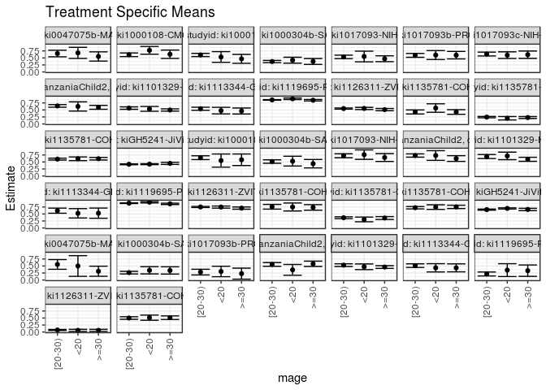

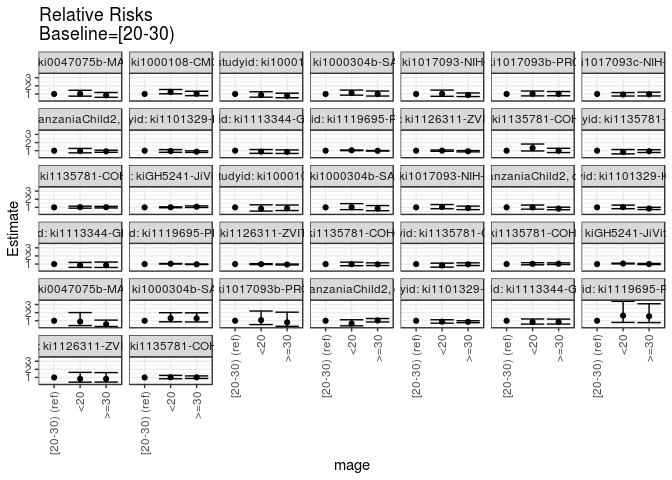

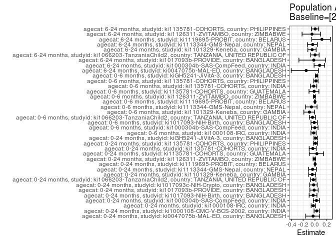

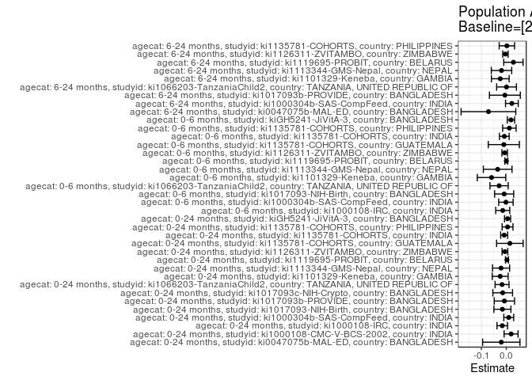

## Results Table

### Parameter: TSM

| agecat | studyid | country | intervention_level | baseline_level | estimate | ci_lower | ci_upper |
| --- | --- | --- | --- | --- | --- | --- | --- |
| 0-24 months | ki0047075b-MAL-ED | BANGLADESH | [20-30) | NA | 0.6571429 | 0.5406898 | 0.7735959 |
| 0-24 months | ki0047075b-MAL-ED | BANGLADESH | <20 | NA | 0.6800000 | 0.4819438 | 0.8780562 |
| 0-24 months | ki0047075b-MAL-ED | BANGLADESH | >=30 | NA | 0.5517241 | 0.3870228 | 0.7164254 |
| 0-24 months | ki1000108-CMC-V-BCS-2002 | INDIA | [20-30) | NA | 0.6126482 | 0.5473590 | 0.6779374 |
| 0-24 months | ki1000108-CMC-V-BCS-2002 | INDIA | <20 | NA | 0.7714286 | 0.6335453 | 0.9093119 |
| 0-24 months | ki1000108-CMC-V-BCS-2002 | INDIA | >=30 | NA | 0.6315789 | 0.4821442 | 0.7810137 |
| 0-24 months | ki1000108-IRC | INDIA | [20-30) | NA | 0.6059701 | 0.5489040 | 0.6630363 |
| 0-24 months | ki1000108-IRC | INDIA | <20 | NA | 0.5333333 | 0.3421602 | 0.7245064 |
| 0-24 months | ki1000108-IRC | INDIA | >=30 | NA | 0.4666667 | 0.3071858 | 0.6261475 |
| 0-24 months | ki1000304b-SAS-CompFeed | INDIA | [20-30) | NA | 0.3709600 | 0.3309047 | 0.4110152 |
| 0-24 months | ki1000304b-SAS-CompFeed | INDIA | <20 | NA | 0.4181782 | 0.3130550 | 0.5233015 |
| 0-24 months | ki1000304b-SAS-CompFeed | INDIA | >=30 | NA | 0.3745200 | 0.2698443 | 0.4791957 |
| 0-24 months | ki1017093-NIH-Birth | BANGLADESH | [20-30) | NA | 0.5358853 | 0.4741944 | 0.5975763 |
| 0-24 months | ki1017093-NIH-Birth | BANGLADESH | <20 | NA | 0.5511033 | 0.3603375 | 0.7418690 |
| 0-24 months | ki1017093-NIH-Birth | BANGLADESH | >=30 | NA | 0.4700242 | 0.3657231 | 0.5743253 |
| 0-24 months | ki1017093b-PROVIDE | BANGLADESH | [20-30) | NA | 0.5906811 | 0.5216357 | 0.6597265 |
| 0-24 months | ki1017093b-PROVIDE | BANGLADESH | <20 | NA | 0.6029482 | 0.4429147 | 0.7629816 |
| 0-24 months | ki1017093b-PROVIDE | BANGLADESH | >=30 | NA | 0.5983838 | 0.4646465 | 0.7321211 |
| 0-24 months | ki1017093c-NIH-Crypto | BANGLADESH | [20-30) | NA | 0.6382446 | 0.5697008 | 0.7067884 |
| 0-24 months | ki1017093c-NIH-Crypto | BANGLADESH | <20 | NA | 0.5988325 | 0.4803468 | 0.7173181 |
| 0-24 months | ki1017093c-NIH-Crypto | BANGLADESH | >=30 | NA | 0.6146783 | 0.4830849 | 0.7462717 |
| 0-24 months | ki1066203-TanzaniaChild2 | TANZANIA, UNITED REPUBLIC OF | [20-30) | NA | 0.6437628 | 0.5972568 | 0.6902688 |
| 0-24 months | ki1066203-TanzaniaChild2 | TANZANIA, UNITED REPUBLIC OF | <20 | NA | 0.6244639 | 0.4592285 | 0.7896993 |
| 0-24 months | ki1066203-TanzaniaChild2 | TANZANIA, UNITED REPUBLIC OF | >=30 | NA | 0.5936098 | 0.5233342 | 0.6638854 |
| 0-24 months | ki1101329-Keneba | GAMBIA | [20-30) | NA | 0.5660656 | 0.5227413 | 0.6093899 |
| 0-24 months | ki1101329-Keneba | GAMBIA | <20 | NA | 0.5378725 | 0.4522019 | 0.6235431 |
| 0-24 months | ki1101329-Keneba | GAMBIA | >=30 | NA | 0.4982364 | 0.4581583 | 0.5383144 |
| 0-24 months | ki1113344-GMS-Nepal | NEPAL | [20-30) | NA | 0.5431688 | 0.4889845 | 0.5973530 |
| 0-24 months | ki1113344-GMS-Nepal | NEPAL | <20 | NA | 0.4762272 | 0.3594032 | 0.5930511 |
| 0-24 months | ki1113344-GMS-Nepal | NEPAL | >=30 | NA | 0.4613604 | 0.3539390 | 0.5687818 |

[output cut: 81 more lines]

### Parameter: E(Y)

| agecat | studyid | country | intervention_level | baseline_level | estimate | ci_lower | ci_upper |
| --- | --- | --- | --- | --- | --- | --- | --- |
| 0-24 months | ki0047075b-MAL-ED | BANGLADESH | NA | NA | 0.6370968 | 0.5511492 | 0.7230443 |
| 0-24 months | ki1000108-CMC-V-BCS-2002 | INDIA | NA | NA | 0.6319018 | 0.5759256 | 0.6878781 |
| 0-24 months | ki1000108-IRC | INDIA | NA | NA | 0.5898734 | 0.5376978 | 0.6420491 |
| 0-24 months | ki1000304b-SAS-CompFeed | INDIA | NA | NA | 0.3808354 | 0.3457640 | 0.4159068 |
| 0-24 months | ki1017093-NIH-Birth | BANGLADESH | NA | NA | 0.5202864 | 0.4695109 | 0.5710618 |
| 0-24 months | ki1017093b-PROVIDE | BANGLADESH | NA | NA | 0.5830619 | 0.5262762 | 0.6398476 |
| 0-24 months | ki1017093c-NIH-Crypto | BANGLADESH | NA | NA | 0.6237942 | 0.5698223 | 0.6777662 |
| 0-24 months | ki1066203-TanzaniaChild2 | TANZANIA, UNITED REPUBLIC OF | NA | NA | 0.6267606 | 0.5890263 | 0.6644948 |
| 0-24 months | ki1101329-Keneba | GAMBIA | NA | NA | 0.5416116 | 0.5143001 | 0.5689232 |
| 0-24 months | ki1113344-GMS-Nepal | NEPAL | NA | NA | 0.5222816 | 0.4773852 | 0.5671781 |
| 0-24 months | ki1119695-PROBIT | BELARUS | NA | NA | 0.8612051 | 0.8511051 | 0.8713052 |
| 0-24 months | ki1126311-ZVITAMBO | ZIMBABWE | NA | NA | 0.5442043 | 0.5277100 | 0.5606986 |
| 0-24 months | ki1135781-COHORTS | GUATEMALA | NA | NA | 0.4421053 | 0.3904403 | 0.4937702 |
| 0-24 months | ki1135781-COHORTS | INDIA | NA | NA | 0.2355670 | 0.2165976 | 0.2545364 |
| 0-24 months | ki1135781-COHORTS | PHILIPPINES | NA | NA | 0.6068680 | 0.5823645 | 0.6313715 |
| 0-24 months | kiGH5241-JiVitA-3 | BANGLADESH | NA | NA | 0.4223660 | 0.4112467 | 0.4334853 |
| 0-6 months | ki1000108-IRC | INDIA | NA | NA | 0.6375000 | 0.5751450 | 0.6998550 |
| 0-6 months | ki1000304b-SAS-CompFeed | INDIA | NA | NA | 0.5131965 | 0.4596632 | 0.5667297 |
| 0-6 months | ki1017093-NIH-Birth | BANGLADESH | NA | NA | 0.7130045 | 0.6535890 | 0.7724200 |
| 0-6 months | ki1066203-TanzaniaChild2 | TANZANIA, UNITED REPUBLIC OF | NA | NA | 0.7020649 | 0.6526590 | 0.7514708 |
| 0-6 months | ki1101329-Keneba | GAMBIA | NA | NA | 0.6352657 | 0.5887450 | 0.6817864 |
| 0-6 months | ki1113344-GMS-Nepal | NEPAL | NA | NA | 0.5833333 | 0.5108676 | 0.6557991 |
| 0-6 months | ki1119695-PROBIT | BELARUS | NA | NA | 0.8855266 | 0.8758983 | 0.8951550 |
| 0-6 months | ki1126311-ZVITAMBO | ZIMBABWE | NA | NA | 0.7443159 | 0.7272505 | 0.7613813 |
| 0-6 months | ki1135781-COHORTS | GUATEMALA | NA | NA | 0.7476636 | 0.6894668 | 0.8058603 |
| 0-6 months | ki1135781-COHORTS | INDIA | NA | NA | 0.3581505 | 0.3318331 | 0.3844678 |
| 0-6 months | ki1135781-COHORTS | PHILIPPINES | NA | NA | 0.7367021 | 0.7051294 | 0.7682749 |
| 0-6 months | kiGH5241-JiVitA-3 | BANGLADESH | NA | NA | 0.6753219 | 0.6619872 | 0.6886567 |
| 6-24 months | ki0047075b-MAL-ED | BANGLADESH | NA | NA | 0.4838710 | 0.3544124 | 0.6133295 |
| 6-24 months | ki1000304b-SAS-CompFeed | INDIA | NA | NA | 0.2854123 | 0.2436284 | 0.3271961 |
| 6-24 months | ki1017093b-PROVIDE | BANGLADESH | NA | NA | 0.2764228 | 0.1950773 | 0.3577682 |
| 6-24 months | ki1066203-TanzaniaChild2 | TANZANIA, UNITED REPUBLIC OF | NA | NA | 0.5579515 | 0.5056058 | 0.6102972 |
| 6-24 months | ki1101329-Keneba | GAMBIA | NA | NA | 0.5063636 | 0.4748679 | 0.5378594 |
| 6-24 months | ki1113344-GMS-Nepal | NEPAL | NA | NA | 0.4934383 | 0.4388573 | 0.5480193 |
| 6-24 months | ki1119695-PROBIT | BELARUS | NA | NA | 0.2440476 | 0.1791134 | 0.3089818 |
| 6-24 months | ki1126311-ZVITAMBO | ZIMBABWE | NA | NA | 0.0691288 | 0.0539734 | 0.0842842 |
| 6-24 months | ki1135781-COHORTS | PHILIPPINES | NA | NA | 0.5026681 | 0.4688378 | 0.5364984 |

### Parameter: RR

| agecat | studyid | country | intervention_level | baseline_level | estimate | ci_lower | ci_upper |
| --- | --- | --- | --- | --- | --- | --- | --- |
| 0-24 months | ki0047075b-MAL-ED | BANGLADESH | [20-30) | [20-30) | 1.0000000 | 1.0000000 | 1.000000 |
| 0-24 months | ki0047075b-MAL-ED | BANGLADESH | <20 | [20-30) | 1.0347826 | 0.7358140 | 1.455225 |
| 0-24 months | ki0047075b-MAL-ED | BANGLADESH | >=30 | [20-30) | 0.8395802 | 0.5929854 | 1.188722 |
| 0-24 months | ki1000108-CMC-V-BCS-2002 | INDIA | [20-30) | [20-30) | 1.0000000 | 1.0000000 | 1.000000 |
| 0-24 months | ki1000108-CMC-V-BCS-2002 | INDIA | <20 | [20-30) | 1.2591705 | 1.0225845 | 1.550493 |
| 0-24 months | ki1000108-CMC-V-BCS-2002 | INDIA | >=30 | [20-30) | 1.0308998 | 0.7952710 | 1.336343 |
| 0-24 months | ki1000108-IRC | INDIA | [20-30) | [20-30) | 1.0000000 | 1.0000000 | 1.000000 |
| 0-24 months | ki1000108-IRC | INDIA | <20 | [20-30) | 0.8801314 | 0.6075574 | 1.274993 |
| 0-24 months | ki1000108-IRC | INDIA | >=30 | [20-30) | 0.7701149 | 0.5402651 | 1.097752 |
| 0-24 months | ki1000304b-SAS-CompFeed | INDIA | [20-30) | [20-30) | 1.0000000 | 1.0000000 | 1.000000 |
| 0-24 months | ki1000304b-SAS-CompFeed | INDIA | <20 | [20-30) | 1.1272867 | 0.8575308 | 1.481900 |
| 0-24 months | ki1000304b-SAS-CompFeed | INDIA | >=30 | [20-30) | 1.0095968 | 0.7479818 | 1.362714 |
| 0-24 months | ki1017093-NIH-Birth | BANGLADESH | [20-30) | [20-30) | 1.0000000 | 1.0000000 | 1.000000 |
| 0-24 months | ki1017093-NIH-Birth | BANGLADESH | <20 | [20-30) | 1.0283978 | 0.7143123 | 1.480588 |
| 0-24 months | ki1017093-NIH-Birth | BANGLADESH | >=30 | [20-30) | 0.8770985 | 0.6830086 | 1.126343 |
| 0-24 months | ki1017093b-PROVIDE | BANGLADESH | [20-30) | [20-30) | 1.0000000 | 1.0000000 | 1.000000 |
| 0-24 months | ki1017093b-PROVIDE | BANGLADESH | <20 | [20-30) | 1.0207676 | 0.7636864 | 1.364390 |
| 0-24 months | ki1017093b-PROVIDE | BANGLADESH | >=30 | [20-30) | 1.0130404 | 0.7870178 | 1.303974 |
| 0-24 months | ki1017093c-NIH-Crypto | BANGLADESH | [20-30) | [20-30) | 1.0000000 | 1.0000000 | 1.000000 |
| 0-24 months | ki1017093c-NIH-Crypto | BANGLADESH | <20 | [20-30) | 0.9382492 | 0.7497957 | 1.174068 |
| 0-24 months | ki1017093c-NIH-Crypto | BANGLADESH | >=30 | [20-30) | 0.9630763 | 0.7580586 | 1.223541 |
| 0-24 months | ki1066203-TanzaniaChild2 | TANZANIA, UNITED REPUBLIC OF | [20-30) | [20-30) | 1.0000000 | 1.0000000 | 1.000000 |
| 0-24 months | ki1066203-TanzaniaChild2 | TANZANIA, UNITED REPUBLIC OF | <20 | [20-30) | 0.9700218 | 0.7372413 | 1.276302 |
| 0-24 months | ki1066203-TanzaniaChild2 | TANZANIA, UNITED REPUBLIC OF | >=30 | [20-30) | 0.9220940 | 0.8025979 | 1.059381 |
| 0-24 months | ki1101329-Keneba | GAMBIA | [20-30) | [20-30) | 1.0000000 | 1.0000000 | 1.000000 |
| 0-24 months | ki1101329-Keneba | GAMBIA | <20 | [20-30) | 0.9501946 | 0.7964369 | 1.133636 |
| 0-24 months | ki1101329-Keneba | GAMBIA | >=30 | [20-30) | 0.8801743 | 0.7880124 | 0.983115 |
| 0-24 months | ki1113344-GMS-Nepal | NEPAL | [20-30) | [20-30) | 1.0000000 | 1.0000000 | 1.000000 |
| 0-24 months | ki1113344-GMS-Nepal | NEPAL | <20 | [20-30) | 0.8767573 | 0.6726313 | 1.142830 |
| 0-24 months | ki1113344-GMS-Nepal | NEPAL | >=30 | [20-30) | 0.8493869 | 0.6592814 | 1.094310 |

[output cut: 81 more lines]

### Parameter: PAR

| agecat | studyid | country | intervention_level | baseline_level | estimate | ci_lower | ci_upper |
| --- | --- | --- | --- | --- | --- | --- | --- |
| 0-24 months | ki0047075b-MAL-ED | BANGLADESH | [20-30) | NA | -0.0200461 | -0.0951000 | 0.0550079 |
| 0-24 months | ki1000108-CMC-V-BCS-2002 | INDIA | [20-30) | NA | 0.0192536 | -0.0087860 | 0.0472932 |
| 0-24 months | ki1000108-IRC | INDIA | [20-30) | NA | -0.0160967 | -0.0373720 | 0.0051786 |
| 0-24 months | ki1000304b-SAS-CompFeed | INDIA | [20-30) | NA | 0.0098754 | -0.0099594 | 0.0297102 |
| 0-24 months | ki1017093-NIH-Birth | BANGLADESH | [20-30) | NA | -0.0155989 | -0.0498775 | 0.0186796 |
| 0-24 months | ki1017093b-PROVIDE | BANGLADESH | [20-30) | NA | -0.0076192 | -0.0485098 | 0.0332713 |
| 0-24 months | ki1017093c-NIH-Crypto | BANGLADESH | [20-30) | NA | -0.0144504 | -0.0540020 | 0.0251012 |
| 0-24 months | ki1066203-TanzaniaChild2 | TANZANIA, UNITED REPUBLIC OF | [20-30) | NA | -0.0170022 | -0.0449758 | 0.0109713 |
| 0-24 months | ki1101329-Keneba | GAMBIA | [20-30) | NA | -0.0244540 | -0.0564694 | 0.0075614 |
| 0-24 months | ki1113344-GMS-Nepal | NEPAL | [20-30) | NA | -0.0208871 | -0.0552746 | 0.0135004 |
| 0-24 months | ki1119695-PROBIT | BELARUS | [20-30) | NA | 0.0028534 | -0.0032582 | 0.0089651 |
| 0-24 months | ki1126311-ZVITAMBO | ZIMBABWE | [20-30) | NA | -0.0054537 | -0.0169671 | 0.0060596 |
| 0-24 months | ki1135781-COHORTS | GUATEMALA | [20-30) | NA | 0.0143570 | -0.0389750 | 0.0676890 |
| 0-24 months | ki1135781-COHORTS | INDIA | [20-30) | NA | -0.0084651 | -0.0225362 | 0.0056060 |
| 0-24 months | ki1135781-COHORTS | PHILIPPINES | [20-30) | NA | 0.0051592 | -0.0166533 | 0.0269717 |
| 0-24 months | kiGH5241-JiVitA-3 | BANGLADESH | [20-30) | NA | 0.0052104 | -0.0070157 | 0.0174365 |
| 0-6 months | ki1000108-IRC | INDIA | [20-30) | NA | -0.0142413 | -0.0424320 | 0.0139495 |
| 0-6 months | ki1000304b-SAS-CompFeed | INDIA | [20-30) | NA | -0.0014335 | -0.0304616 | 0.0275946 |
| 0-6 months | ki1017093-NIH-Birth | BANGLADESH | [20-30) | NA | -0.0085145 | -0.0467921 | 0.0297631 |
| 0-6 months | ki1066203-TanzaniaChild2 | TANZANIA, UNITED REPUBLIC OF | [20-30) | NA | -0.0288768 | -0.0655418 | 0.0077881 |
| 0-6 months | ki1101329-Keneba | GAMBIA | [20-30) | NA | -0.0592410 | -0.1165232 | -0.0019587 |
| 0-6 months | ki1113344-GMS-Nepal | NEPAL | [20-30) | NA | -0.0345620 | -0.0922029 | 0.0230790 |
| 0-6 months | ki1119695-PROBIT | BELARUS | [20-30) | NA | 0.0001170 | -0.0057885 | 0.0060225 |
| 0-6 months | ki1126311-ZVITAMBO | ZIMBABWE | [20-30) | NA | -0.0064558 | -0.0175630 | 0.0046514 |
| 0-6 months | ki1135781-COHORTS | GUATEMALA | [20-30) | NA | -0.0099122 | -0.0724377 | 0.0526132 |
| 0-6 months | ki1135781-COHORTS | INDIA | [20-30) | NA | -0.0078897 | -0.0273807 | 0.0116012 |
| 0-6 months | ki1135781-COHORTS | PHILIPPINES | [20-30) | NA | 0.0124663 | -0.0145532 | 0.0394857 |
| 0-6 months | kiGH5241-JiVitA-3 | BANGLADESH | [20-30) | NA | 0.0190486 | 0.0045447 | 0.0335526 |
| 6-24 months | ki0047075b-MAL-ED | BANGLADESH | [20-30) | NA | -0.0716846 | -0.1816278 | 0.0382586 |
| 6-24 months | ki1000304b-SAS-CompFeed | INDIA | [20-30) | NA | 0.0224806 | -0.0030551 | 0.0480164 |
| 6-24 months | ki1017093b-PROVIDE | BANGLADESH | [20-30) | NA | -0.0056285 | -0.0676577 | 0.0564006 |
| 6-24 months | ki1066203-TanzaniaChild2 | TANZANIA, UNITED REPUBLIC OF | [20-30) | NA | 0.0010350 | -0.0387612 | 0.0408311 |
| 6-24 months | ki1101329-Keneba | GAMBIA | [20-30) | NA | -0.0241793 | -0.0598367 | 0.0114781 |
| 6-24 months | ki1113344-GMS-Nepal | NEPAL | [20-30) | NA | -0.0191498 | -0.0601908 | 0.0218913 |
| 6-24 months | ki1119695-PROBIT | BELARUS | [20-30) | NA | 0.0286630 | -0.0101059 | 0.0674319 |
| 6-24 months | ki1126311-ZVITAMBO | ZIMBABWE | [20-30) | NA | -0.0034550 | -0.0142370 | 0.0073270 |
| 6-24 months | ki1135781-COHORTS | PHILIPPINES | [20-30) | NA | 0.0024033 | -0.0285338 | 0.0333405 |

### Parameter: PAF

| agecat | studyid | country | intervention_level | baseline_level | estimate | ci_lower | ci_upper |
| --- | --- | --- | --- | --- | --- | --- | --- |
| 0-24 months | ki0047075b-MAL-ED | BANGLADESH | [20-30) | NA | -0.0314647 | -0.1561481 | 0.0797723 |
| 0-24 months | ki1000108-CMC-V-BCS-2002 | INDIA | [20-30) | NA | 0.0304693 | -0.0153283 | 0.0742012 |
| 0-24 months | ki1000108-IRC | INDIA | [20-30) | NA | -0.0272885 | -0.0639884 | 0.0081456 |
| 0-24 months | ki1000304b-SAS-CompFeed | INDIA | [20-30) | NA | 0.0259309 | -0.0275922 | 0.0766662 |
| 0-24 months | ki1017093-NIH-Birth | BANGLADESH | [20-30) | NA | -0.0299815 | -0.0980405 | 0.0338591 |
| 0-24 months | ki1017093b-PROVIDE | BANGLADESH | [20-30) | NA | -0.0130676 | -0.0857331 | 0.0547345 |
| 0-24 months | ki1017093c-NIH-Crypto | BANGLADESH | [20-30) | NA | -0.0231654 | -0.0884993 | 0.0382471 |
| 0-24 months | ki1066203-TanzaniaChild2 | TANZANIA, UNITED REPUBLIC OF | [20-30) | NA | -0.0271272 | -0.0728093 | 0.0166098 |
| 0-24 months | ki1101329-Keneba | GAMBIA | [20-30) | NA | -0.0451504 | -0.1058655 | 0.0122312 |
| 0-24 months | ki1113344-GMS-Nepal | NEPAL | [20-30) | NA | -0.0399920 | -0.1083674 | 0.0241653 |
| 0-24 months | ki1119695-PROBIT | BELARUS | [20-30) | NA | 0.0033133 | -0.0038098 | 0.0103859 |
| 0-24 months | ki1126311-ZVITAMBO | ZIMBABWE | [20-30) | NA | -0.0100215 | -0.0314042 | 0.0109180 |
| 0-24 months | ki1135781-COHORTS | GUATEMALA | [20-30) | NA | 0.0324742 | -0.0959122 | 0.1458200 |
| 0-24 months | ki1135781-COHORTS | INDIA | [20-30) | NA | -0.0359351 | -0.0972853 | 0.0219850 |
| 0-24 months | ki1135781-COHORTS | PHILIPPINES | [20-30) | NA | 0.0085013 | -0.0281263 | 0.0438241 |
| 0-24 months | kiGH5241-JiVitA-3 | BANGLADESH | [20-30) | NA | 0.0123362 | -0.0170406 | 0.0408645 |
| 0-6 months | ki1000108-IRC | INDIA | [20-30) | NA | -0.0223393 | -0.0676463 | 0.0210451 |
| 0-6 months | ki1000304b-SAS-CompFeed | INDIA | [20-30) | NA | -0.0027933 | -0.0609840 | 0.0522059 |
| 0-6 months | ki1017093-NIH-Birth | BANGLADESH | [20-30) | NA | -0.0119417 | -0.0670961 | 0.0403619 |
| 0-6 months | ki1066203-TanzaniaChild2 | TANZANIA, UNITED REPUBLIC OF | [20-30) | NA | -0.0411313 | -0.0950270 | 0.0101118 |
| 0-6 months | ki1101329-Keneba | GAMBIA | [20-30) | NA | -0.0932538 | -0.1878923 | -0.0061551 |
| 0-6 months | ki1113344-GMS-Nepal | NEPAL | [20-30) | NA | -0.0592491 | -0.1634303 | 0.0356030 |
| 0-6 months | ki1119695-PROBIT | BELARUS | [20-30) | NA | 0.0001321 | -0.0065590 | 0.0067789 |
| 0-6 months | ki1126311-ZVITAMBO | ZIMBABWE | [20-30) | NA | -0.0086735 | -0.0237094 | 0.0061416 |
| 0-6 months | ki1135781-COHORTS | GUATEMALA | [20-30) | NA | -0.0132576 | -0.1004856 | 0.0670564 |
| 0-6 months | ki1135781-COHORTS | INDIA | [20-30) | NA | -0.0220291 | -0.0779221 | 0.0309657 |
| 0-6 months | ki1135781-COHORTS | PHILIPPINES | [20-30) | NA | 0.0169217 | -0.0204926 | 0.0529643 |
| 0-6 months | kiGH5241-JiVitA-3 | BANGLADESH | [20-30) | NA | 0.0282067 | 0.0064671 | 0.0494707 |
| 6-24 months | ki0047075b-MAL-ED | BANGLADESH | [20-30) | NA | -0.1481481 | -0.4017062 | 0.0595432 |
| 6-24 months | ki1000304b-SAS-CompFeed | INDIA | [20-30) | NA | 0.0787655 | -0.0148143 | 0.1637159 |
| 6-24 months | ki1017093b-PROVIDE | BANGLADESH | [20-30) | NA | -0.0203620 | -0.2715476 | 0.1812036 |
| 6-24 months | ki1066203-TanzaniaChild2 | TANZANIA, UNITED REPUBLIC OF | [20-30) | NA | 0.0018550 | -0.0720860 | 0.0706963 |
| 6-24 months | ki1101329-Keneba | GAMBIA | [20-30) | NA | -0.0477509 | -0.1205874 | 0.0203514 |
| 6-24 months | ki1113344-GMS-Nepal | NEPAL | [20-30) | NA | -0.0388088 | -0.1260324 | 0.0416583 |
| 6-24 months | ki1119695-PROBIT | BELARUS | [20-30) | NA | 0.1174484 | -0.0545543 | 0.2613967 |
| 6-24 months | ki1126311-ZVITAMBO | ZIMBABWE | [20-30) | NA | -0.0499792 | -0.2183998 | 0.0951606 |
| 6-24 months | ki1135781-COHORTS | PHILIPPINES | [20-30) | NA | 0.0047812 | -0.0587113 | 0.0644659 |